# Kats. Lab_1. NLP

```python
# This Python 3 environment comes with many helpful analytics libraries installed
# It is defined by the kaggle/python docker image: https://github.com/kaggle/docker-python
# For example, here's several helpful packages to load in

import numpy as np # linear algebra
import pandas as pd # data processing, CSV file I/O (e.g. pd.read_csv)

# Input data files are available in the "../input/" directory.
# For example, running this (by clicking run or pressing Shift+Enter) will list the files in the input directory

import os
print(os.listdir("../input"))

# Any results you write to the current directory are saved as output.


import csv
import matplotlib.pyplot as plt
import seaborn as sns

import time
start_time = time.time()
import sys, os, re, csv, codecs, numpy as np, pandas as pd
np.random.seed(32)

from keras.models import Model, load_model
from keras import initializers, regularizers, constraints, optimizers, layers, callbacks
from keras import backend as K
from keras.engine import InputSpec, Layer

import nltk
import re
from nltk.corpus import stopwords
from nltk.corpus import wordnet
from nltk.stem import SnowballStemmer
from string import punctuation

from keras.preprocessing.text import Tokenizer
from keras.preprocessing.sequence import pad_sequences
from keras.layers import *
from keras.layers import concatenate, CuDNNGRU
from keras.layers.normalization import BatchNormalization
from keras.callbacks import EarlyStopping, ModelCheckpoint

import sys

from keras import backend as K
from keras.engine.topology import Layer
from keras import initializers, regularizers, constraints
import logging
from sklearn.metrics import roc_auc_score
from keras.callbacks import Callback

class RocAucEvaluation(Callback):
    def __init__(self, validation_data=(), interval=1):
        super(Callback, self).__init__()

        self.interval = interval
        self.X_val, self.y_val = validation_data

    def on_epoch_end(self, epoch, logs={}):
        if epoch % self.interval == 0:
            y_pred = self.model.predict(self.X_val, verbose=0)
            score = roc_auc_score(self.y_val, y_pred)
            print("\n ROC-AUC - epoch: {:d} - score: {:.6f}".format(epoch+1, score))
```

```
['fasttext-crawl-300d-2m', '2s-lab1']
```

```python
import sys
import warnings

if not sys.warnoptions:
    warnings.simplefilter("ignore")
```

```python
test_data = pd.read_csv("../input/2s-lab1/test.csv")
test_data.head(10)
```

|  | id | comment_text |
| --- | --- | --- |
| 0 | 150000 | Dmacks consitatnly edits other peoples pages a... |
| 1 | 150001 | == Contested deletion == \n\n This article sho... |
| 2 | 150002 | March 2008\n Please stop. If you continue to v... |
| 3 | 150003 | "}\n\nAugust Esperanza Newsletter\n{\| style=""... |
| 4 | 150004 | William Sledd\n\nOK, it is time We Tubers had ... |
| 5 | 150005 | "\n\n Please apologize: you made a clear mista... |
| 6 | 150006 | What makes and egg crack? \n FORCE!!!!!!!!! \n... |
| 7 | 150007 | " \n :::::No, your comparison is invalid. Your... |
| 8 | 150008 | The Tree in a Test Tube, 1942 (full).ogv\|The T... |
| 9 | 150009 | :::I should have listened to your advice. Alan... |

```python
train_data = pd.read_csv("../input/2s-lab1/train.csv")
train_data.head(10)
```

|  | id | comment_text | toxic | severe_toxic | obscene | threat | insult | identity_hate |
| --- | --- | --- | --- | --- | --- | --- | --- | --- |
| 0 | 0 | Gaelic translation \n\nHi, don't suppose you c... | 0 | 0 | 0 | 0 | 0 | 0 |
| 1 | 1 | Hey dick \nYou don't know what is copyright so... | 1 | 0 | 1 | 0 | 1 | 0 |
| 2 | 2 | "\n\nAm I correct in thinking that you are ref... | 0 | 0 | 0 | 0 | 0 | 0 |
| 3 | 3 | == Notable Alumni == \n\n Why was this section... | 0 | 0 | 0 | 0 | 0 | 0 |
| 4 | 4 | I have already been sent this message about va... | 1 | 0 | 1 | 0 | 1 | 0 |
| 5 | 5 | == exuse me == \n\n i was not attacking someon... | 0 | 0 | 0 | 0 | 0 | 0 |
| 6 | 6 | :You're welcome, Vernon39! Thanks for your imp... | 0 | 0 | 0 | 0 | 0 | 0 |
| 7 | 7 | Good point by JonC , legally the name of the s... | 0 | 0 | 0 | 0 | 0 | 0 |
| 8 | 8 | "\nNo such ""compromise"" was reached on Septe... | 0 | 0 | 0 | 0 | 0 | 0 |
| 9 | 9 | :::Again, we can't take the unverifiable claim... | 0 | 0 | 0 | 0 | 0 | 0 |

```python
test_data.isnull().sum()
```

```
id              0
comment_text    0
dtype: int64
```

```python
train_data.isnull().sum()
```

```
id               0
comment_text     0
toxic            0
severe_toxic     0
obscene          0
threat           0
insult           0
identity_hate    0
dtype: int64
```

```python
rowSums = train_data.iloc[:,2:].sum(axis=1)
clean_comments_count = (rowSums==0).sum(axis=0)

print("Total number of comments = ",len(train_data))
print("Number of clean comments = ",clean_comments_count)
print("Number of comments with labels =",(len(train_data)-clean_comments_count))
```

```
Total number of comments =  150000
Number of clean comments =  134916
Number of comments with labels = 15084
```

```python
categories = list(train_data.columns.values)
categories = categories[2:]
print(categories)
```

```
['toxic', 'severe_toxic', 'obscene', 'threat', 'insult', 'identity_hate']
```

```python
counts = []
for category in categories:
    counts.append((category, train_data[category].sum()))
df_stats = pd.DataFrame(counts, columns=['category', 'number of comments'])
df_stats
```

|  | category | number of comments |
| --- | --- | --- |
| 0 | toxic | 14353 |
| 1 | severe_toxic | 1329 |
| 2 | obscene | 8155 |
| 3 | threat | 475 |
| 4 | insult | 7595 |
| 5 | identity_hate | 1418 |

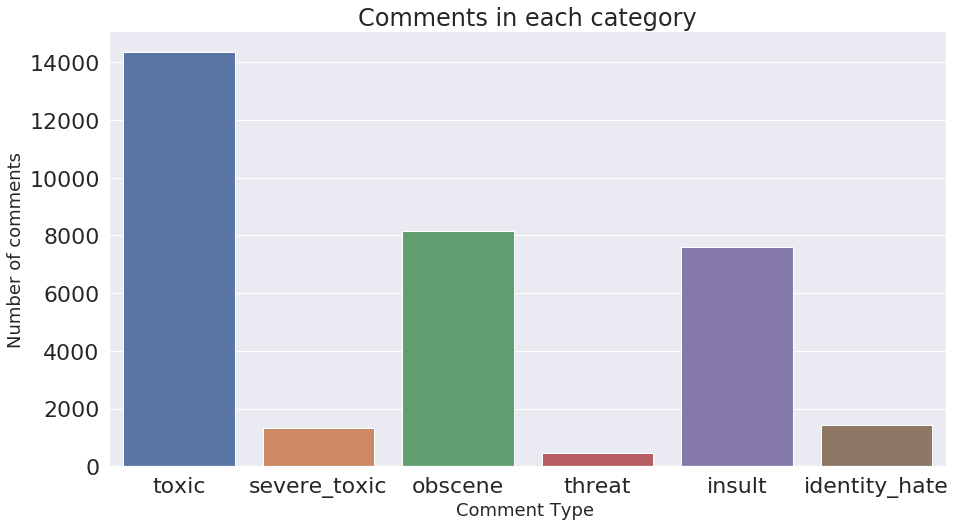

```python
sns.set(font_scale = 2)
plt.figure(figsize=(15,8))

ax= sns.barplot(categories, train_data.iloc[:,2:].sum().values)

plt.title("Comments in each category", fontsize=24)
plt.ylabel('Number of comments', fontsize=18)
plt.xlabel('Comment Type ', fontsize=18)
```

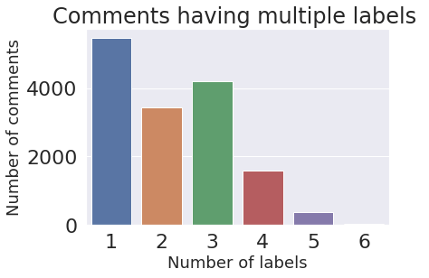

```python
multiLabel_counts = rowSums.value_counts()
multiLabel_counts = multiLabel_counts.iloc[1:]
ax = sns.barplot(multiLabel_counts.index, multiLabel_counts.values)

plt.title("Comments having multiple labels ")
plt.ylabel('Number of comments', fontsize=18)
plt.xlabel('Number of labels', fontsize=18)
plt.show()
```

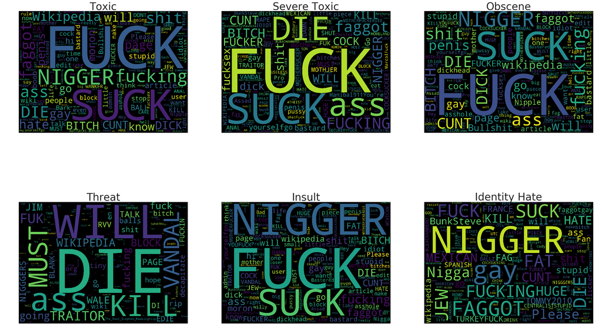

```python
from wordcloud import WordCloud,STOPWORDS

plt.figure(figsize=(40,25))

# toxic
subset = train_data[train_data.toxic==1]
text = subset.comment_text.values
cloud_toxic = WordCloud(
                          stopwords=STOPWORDS,
                          background_color='black',
                          collocations=False,
                          width=2500,
                          height=1800
                         ).generate(" ".join(text))

plt.subplot(2, 3, 1)
plt.axis('off')
plt.title("Toxic",fontsize=40)
plt.imshow(cloud_toxic)


# severe_toxic
subset = train_data[train_data.severe_toxic==1]
text = subset.comment_text.values
cloud_severe_toxic = WordCloud(
                          stopwords=STOPWORDS,
                          background_color='black',
                          collocations=False,
                          width=2500,
                          height=1800
                         ).generate(" ".join(text))

plt.subplot(2, 3, 2)
plt.axis('off')
plt.title("Severe Toxic",fontsize=40)
plt.imshow(cloud_severe_toxic)


# obscene
subset = train_data[train_data.obscene==1]
text = subset.comment_text.values
cloud_obscene = WordCloud(
                          stopwords=STOPWORDS,
                          background_color='black',
                          collocations=False,
                          width=2500,
                          height=1800
                         ).generate(" ".join(text))

plt.subplot(2, 3, 3)
plt.axis('off')
plt.title("Obscene",fontsize=40)
plt.imshow(cloud_obscene)


# threat
subset = train_data[train_data.threat==1]
text = subset.comment_text.values
cloud_threat = WordCloud(
                          stopwords=STOPWORDS,
                          background_color='black',
                          collocations=False,
                          width=2500,
                          height=1800
                         ).generate(" ".join(text))

plt.subplot(2, 3, 4)
plt.axis('off')
plt.title("Threat",fontsize=40)
plt.imshow(cloud_threat)


# insult
subset = train_data[train_data.insult==1]
text = subset.comment_text.values
cloud_insult = WordCloud(
                          stopwords=STOPWORDS,
                          background_color='black',
                          collocations=False,
                          width=2500,
                          height=1800
                         ).generate(" ".join(text))

plt.subplot(2, 3, 5)
plt.axis('off')
plt.title("Insult",fontsize=40)
plt.imshow(cloud_insult)


# identity_hate
subset = train_data[train_data.identity_hate==1]
text = subset.comment_text.values
cloud_identity_hate = WordCloud(
                          stopwords=STOPWORDS,
                          background_color='black',
                          collocations=False,
                          width=2500,
                          height=1800
                         ).generate(" ".join(text))

plt.subplot(2, 3, 6)
plt.axis('off')
plt.title("Identity Hate",fontsize=40)
plt.imshow(cloud_identity_hate)

plt.show()
```

Выглядит как современное искусство.

```python
data = train_data
data = train_data.loc[np.random.choice(train_data.index, size=4000)]
data.shape
```

```
(4000, 8)
```

Обработаем данные. Уберем из них всё, что кажется лишним. Более подробный анализ я проводила в кёрнеле.

```python
def cleanData(text):
    text = text.lower().split()
    text = " ".join(text)
    text = re.sub(r"[^A-Za-z0-9^,!.\/'+\-=]", " ", text)
    text = re.sub(r"what's", "what is ", text)
    text = re.sub(r"\'s", " ", text)
    text = re.sub(r"\'ve", " have ", text)
    text = re.sub(r"can't", "cannot ", text)
    text = re.sub(r"n't", " not ", text)
    text = re.sub(r"i'm", "i am ", text)
    text = re.sub(r"\'re", " are ", text)
    text = re.sub(r"\'d", " would ", text)
    text = re.sub(r"\'ll", " will ", text)
    text = re.sub(r",", " ", text)
    text = re.sub(r"\.", " ", text)
    text = re.sub(r"!", " ! ", text)
    text = re.sub(r"\/", " ", text)
    text = re.sub(r"\^", " ^ ", text)
    text = re.sub(r"\+", " + ", text)
    text = re.sub(r"\-", " - ", text)
    text = re.sub(r"\=", " = ", text)
    text = re.sub(r"'", " ", text)
    text = re.sub(r"(\d+)(k)", r"\g<1>000", text)
    text = re.sub(r":", " : ", text)
    text = re.sub(r" e g ", " eg ", text)
    text = re.sub(r" b g ", " bg ", text)
    text = re.sub(r" u s ", " american ", text)
    text = re.sub(r"\0s", "0", text)
    text = re.sub(r" 9 11 ", "911", text)
    text = re.sub(r"e - mail", "email", text)
    text = re.sub(r"j k", "jk", text)
    text = re.sub(r"\s{2,}", " ", text)
    return text
```

```python
import sys
import warnings

if not sys.warnoptions:
    warnings.simplefilter("ignore")
```

```python
data['comment_text'] = data['comment_text'].str.lower()
data['comment_text'] = data['comment_text'].apply(cleanData)
data.head()
```

|  | id | comment_text | toxic | severe_toxic | obscene | threat | insult | identity_hate |
| --- | --- | --- | --- | --- | --- | --- | --- | --- |
| 10967 | 10967 | can we get a photo of a human penis on this pa... | 1 | 0 | 0 | 0 | 0 | 0 |
| 108075 | 108075 | take care i did not know you well but you cam... | 0 | 0 | 0 | 0 | 0 | 0 |
| 130949 | 130949 | the problem in detail is that you created the... | 0 | 0 | 0 | 0 | 0 | 0 |
| 75062 | 75062 | see ani report | 0 | 0 | 0 | 0 | 0 | 0 |
| 60284 | 60284 | barek my post on barek talk page was not an at... | 1 | 0 | 0 | 0 | 0 | 0 |

```python
stop_words = set(stopwords.words('english'))
stop_words.update(['zero','one','two','three','four','five','six','seven','eight','nine','ten','may','also','across','among','beside','however','yet','within'])
re_stop_words = re.compile(r"\b(" + "|".join(stop_words) + ")\\W", re.I)
def removeStopWords(sentence):
    global re_stop_words
    return re_stop_words.sub(" ", sentence)
replace_numbers=re.compile(r'\d+',re.IGNORECASE)

data['comment_text'] = data['comment_text'].apply(removeStopWords)
data.head()
```

|  | id | comment_text | toxic | severe_toxic | obscene | threat | insult | identity_hate |
| --- | --- | --- | --- | --- | --- | --- | --- | --- |
| 10967 | 10967 | get photo human penis page comparison | 1 | 0 | 0 | 0 | 0 | 0 |
| 108075 | 108075 | take care know well came nice person... | 0 | 0 | 0 | 0 | 0 | 0 |
| 130949 | 130949 | problem detail created article sole p... | 0 | 0 | 0 | 0 | 0 | 0 |
| 75062 | 75062 | see ani report | 0 | 0 | 0 | 0 | 0 | 0 |
| 60284 | 60284 | barek post barek talk page attack virt... | 1 | 0 | 0 | 0 | 0 | 0 |

Приведем слова к начальной форме.

```python
stemmer = SnowballStemmer("english")
def stemming(sentence):
    stemSentence = ""
    for word in sentence.split():
        stem = stemmer.stem(word)
        stemSentence += stem
        stemSentence += " "
    stemSentence = stemSentence.strip()
    return stemSentence

data['comment_text'] = data['comment_text'].apply(stemming)
data.head()
```

|  | id | comment_text | toxic | severe_toxic | obscene | threat | insult | identity_hate |
| --- | --- | --- | --- | --- | --- | --- | --- | --- |
| 10967 | 10967 | get photo human peni page comparison | 1 | 0 | 0 | 0 | 0 | 0 |
| 108075 | 108075 | take care know well came nice person truli los... | 0 | 0 | 0 | 0 | 0 | 0 |
| 130949 | 130949 | problem detail creat articl sole purpos put li... | 0 | 0 | 0 | 0 | 0 | 0 |
| 75062 | 75062 | see ani report | 0 | 0 | 0 | 0 | 0 | 0 |
| 60284 | 60284 | barek post barek talk page attack virtual slap... | 1 | 0 | 0 | 0 | 0 | 0 |

```python
from sklearn.model_selection import train_test_split

train, test = train_test_split(data, random_state=42, test_size=0.30, shuffle=True)

print(train.shape)
print(test.shape)
```

```
(2800, 8)
(1200, 8)
```

```python
train_text = train['comment_text']
test_text = test['comment_text']
```

Векторизуем.

```python
from sklearn.feature_extraction.text import TfidfVectorizer
vectorizer = TfidfVectorizer(strip_accents='unicode', analyzer='word', ngram_range=(1,3), norm='l2')
vectorizer.fit(train_text)
vectorizer.fit(test_text)
```

```
TfidfVectorizer(analyzer='word', binary=False, decode_error='strict',
        dtype=<class 'numpy.float64'>, encoding='utf-8', input='content',
        lowercase=True, max_df=1.0, max_features=None, min_df=1,
        ngram_range=(1, 3), norm='l2', preprocessor=None, smooth_idf=True,
        stop_words=None, strip_accents='unicode', sublinear_tf=False,
        token_pattern='(?u)\\b\\w\\w+\\b', tokenizer=None, use_idf=True,
        vocabulary=None)
```

```python
x_train = vectorizer.transform(train_text)
y_train = train.drop(labels = ['id','comment_text'], axis=1)

x_test = vectorizer.transform(test_text)
y_test = test.drop(labels = ['id','comment_text'], axis=1)
```

```python
from sklearn.linear_model import LogisticRegression
from sklearn.pipeline import Pipeline
from sklearn.metrics import accuracy_score
from sklearn.multiclass import OneVsRestClassifier
```

Начнем классифицировать. В рамках этой работы я попоробовала многие классификаторы. Часть из них представлена в этой тетрадке, другая - в моем публичном кёрнеле.

One Vs Rest Classifier

```python
%%time
LogReg_pipeline = Pipeline([
                ('clf', OneVsRestClassifier(LogisticRegression(solver='sag'), n_jobs=-1)),
            ])

for category in categories:
    print('**Processing {} comments...**'.format(category))


    pred = LogReg_pipeline.fit(x_train, train[category])


    prediction = LogReg_pipeline.predict(x_test)
    print('Test accuracy is {}'.format(accuracy_score(test[category], prediction)))
    print("\n")
```

```
**Processing toxic comments...**
Test accuracy is 0.9091666666666667


**Processing severe_toxic comments...**
Test accuracy is 0.9941666666666666


**Processing obscene comments...**
Test accuracy is 0.95


**Processing threat comments...**
Test accuracy is 1.0


**Processing insult comments...**
Test accuracy is 0.95


**Processing identity_hate comments...**
Test accuracy is 0.9891666666666666


CPU times: user 68 ms, sys: 56 ms, total: 124 ms
Wall time: 4.67 s
```

Binary Relevance

```python
%%time

from skmultilearn.problem_transform import BinaryRelevance
from sklearn.naive_bayes import GaussianNB

classifier = BinaryRelevance(GaussianNB())

classifier.fit(x_train, y_train)

predictions = classifier.predict(x_test.toarray())

print("Accuracy = ",accuracy_score(y_test,predictions))
print("\n")
```

```
Accuracy =  0.87


CPU times: user 21.8 s, sys: 23.5 s, total: 45.2 s
Wall time: 45.3 s
```

Опыт интересный, но нам нужны результаты лучше.

Время экспериментов!

Попробуем поработать с готовыми эмбедингами.

```python
train = pd.read_csv('../input/2s-lab1/train.csv')
test = pd.read_csv('../input/2s-lab1/test.csv')
list_classes = ["toxic", "severe_toxic", "obscene", "threat", "insult", "identity_hate"]
y = train[list_classes].values
list_sentences_train = train["comment_text"]
list_sentences_test = test["comment_text"]
```

```python
WORDS = {}
index = [1]

def get_coefs(word, *arr):
    WORDS[word] = index[0]
    index[0] = index[0]+1
    return word, np.asarray(arr, dtype='float32')
embeddings_index = dict(get_coefs(*o.rstrip().rsplit(' ')) for o in open('../input/fasttext-crawl-300d-2m/crawl-300d-2M.vec'))

def P(word):
    return - WORDS.get(word, 0)

def correction(word):
    return max(candidates(word), key=P)

def candidates(word):
    return (known([word]) or known(edits1(word)) or [word])

def known(words):
    return set(w for w in words if w in WORDS)

def edits1(word):
    letters    = 'abcdefghijklmnopqrstuvwxyz'
    splits     = [(word[:i], word[i:])    for i in range(len(word) + 1)]
    deletes    = [L + R[1:]               for L, R in splits if R]
    transposes = [L + R[1] + R[0] + R[2:] for L, R in splits if len(R)>1]
    replaces   = [L + c + R[1:]           for L, R in splits if R for c in letters]
    inserts    = [L + c + R               for L, R in splits for c in letters]
    return set(deletes + transposes + replaces + inserts)
```

```python
print(train.head())
cols  = list(train.columns.values)
cols.remove('id')
cols.remove('comment_text')
print(cols)
```

```
   id      ...      identity_hate
0   0      ...                  0
1   1      ...                  0
2   2      ...                  0
3   3      ...                  0
4   4      ...                  0

[5 rows x 8 columns]
['toxic', 'severe_toxic', 'obscene', 'threat', 'insult', 'identity_hate']
```

```python
def corrected_words(row):
    comment = row['comment_text']
    result =  ' '
    for w in nltk.word_tokenize(comment):
        if len(w)>1 and not wordnet.synsets(w):
            result += correction(w) + ' '
        else:
            result += w + ' '

    return result
```

```python
train['comment_text'] = train.apply(corrected_words, axis=1)
test['comment_text'] = test.apply(corrected_words, axis=1)
```

```python
#токенизация текста
max_features = 25000
max_len=100

tokenizer = Tokenizer(num_words=max_features)
tokenizer.fit_on_texts(train['comment_text'])
tokenizer.fit_on_texts(test['comment_text'])
def process_text(data):
    sequences = tokenizer.texts_to_sequences(data)
    return pad_sequences(sequences=sequences, maxlen=max_len)

train_data = process_text(train['comment_text'])
test_data = process_text(test['comment_text'])
input_dim = np.max([np.max(train_data), np.max(test_data)]) + 1
embedding_dims = 300
print(input_dim)
```

```
25000
```

```python
# Загружаем готовый эмбединг
word_index = tokenizer.word_index

nb_words = min(max_features, len(word_index))
embedding_matrix = np.zeros((nb_words, embedding_dims))
for word, i in word_index.items():
    if i >= max_features: continue
    embedding_vector = embeddings_index.get(word)
    if embedding_vector is not None: embedding_matrix[i] = embedding_vector
```

```python
#Строим модель [Embedding and CNN]
def clf_model():
    seq = Input(shape=(max_len,), name='seq')
    l = Embedding(max_features, embedding_dims, weights=[embedding_matrix])(seq)
    l = SpatialDropout1D(0.4)(l)
    c2 = Conv1D(embedding_dims,2, activation='relu')(l)
    c3 = Conv1D(embedding_dims,3, activation='relu')(l)
    c4 = Conv1D(embedding_dims,4, activation='relu')(l)
    c5 = Conv1D(embedding_dims,5, activation='relu')(l)
    max_pool2 = GlobalMaxPooling1D()(c2)
    max_pool3 = GlobalMaxPooling1D()(c3)
    max_pool4 = GlobalMaxPooling1D()(c4)
    max_pool5 = GlobalMaxPooling1D()(c5)
    conc = concatenate([max_pool2,max_pool3,max_pool4,max_pool5])
    conc = Dense(36)(conc)
    output = Dense(6, activation='sigmoid', name='output')(conc)
    model = Model(inputs=[seq], outputs=output)
    model.compile(loss='binary_crossentropy',optimizer='adam')
    return model
```

```python
class RocAucEvaluation(Callback):
    def __init__(self, validation_data=(), interval=1):
        super(Callback, self).__init__()

        self.interval = interval
        self.X_val, self.y_val = validation_data

    def on_epoch_end(self, epoch, logs={}):
        if epoch % self.interval == 0:
            y_pred = self.model.predict(self.X_val, verbose=0)
            score = roc_auc_score(self.y_val, y_pred)
            print("\n ROC-AUC - epoch: %d - score: %.6f \n" % (epoch+1, score))
```

```python
print("Погнали")
x_train, x_test, y_train, y_test = train_test_split(train_data, train[cols], test_size = 0.05, random_state = 144)
RocAuc = RocAucEvaluation(validation_data=(x_test, y_test), interval=1)
text_clf = clf_model()
submission = pd.DataFrame()
submission['id'] = test.id
text_clf.fit(x_train, y_train, batch_size=50, epochs=2, validation_data=(x_test, y_test), callbacks=[RocAuc], verbose=0)
pred = text_clf.predict(test_data)
i=0
for col in cols:
    submission[col] = pred[:,i]
    i+=1
submission.to_csv('submission_cnn.csv', index=False)
```

[output not shown]

```python
submission = pd.read_csv('../input/2s-lab1/sample_submission.csv')
submission[['toxic', 'severe_toxic', 'obscene', 'threat', 'insult', 'identity_hate']] = pred
submission.to_csv('mbc_2.csv', index=False)
```

Удивительно, но эта модель с результатом в 0.978939 после обучения показала точность в 0.98541 на открытой части данных.

Попробуем рекуррентную нейронную сеть вида LSTM. Исследование показало, что она хороша для задач такого рода.

Данные чистить не будем, потому что я пробовала, получился результат хуже.

```python
train = pd.read_csv('../input/2s-lab1/train.csv')
test = pd.read_csv('../input/2s-lab1/test.csv')
list_classes = ["toxic", "severe_toxic", "obscene", "threat", "insult", "identity_hate"]
y = train[list_classes].values
list_sentences_train = train["comment_text"]
list_sentences_test = test["comment_text"]
```

```python
max_features = 20000
tokenizer = Tokenizer(num_words=max_features)
tokenizer.fit_on_texts(list(list_sentences_train))
list_tokenized_train = tokenizer.texts_to_sequences(list_sentences_train)
list_tokenized_test = tokenizer.texts_to_sequences(list_sentences_test)
```

```python
list_tokenized_train[:1]
```

```
[[9381,
  1599,
  159,
  59,
  1669,
  6,
  104,
  118,
  37,
  78,
  21,
  5,
  9381,
  1599,
  12,
  93,
  10,
  2052,
  22,
  172,
  554,
  2]]
```

```python
maxlen = 200
x_train = pad_sequences(list_tokenized_train, maxlen=maxlen)
x_test = pad_sequences(list_tokenized_test, maxlen=maxlen)
inp = Input(shape=(maxlen, ))
embed_size = 128
x = Embedding(max_features, embed_size)(inp)
x = LSTM(60, return_sequences=True,name='lstm_layer')(x)
x = GlobalMaxPool1D()(x)
x = Dropout(0.1)(x)
x = Dense(50, activation="relu")(x)
x = Dropout(0.1)(x)
x = Dense(6, activation="sigmoid")(x)
model = Model(inputs=inp, outputs=x)
model.compile(loss='binary_crossentropy',
                  optimizer='adam',
                  metrics=['accuracy'])
```

```python
batch_size = 32
epochs = 2
model.fit(x_train,y, batch_size=batch_size, epochs=epochs, validation_split=0.1)
```

```
Train on 135000 samples, validate on 15000 samples
```

```
<keras.callbacks.History at 0x7f604ae6fe80>
```

```python
predictions = model.predict(x_test,batch_size=32,verbose=1)
```

```python
submission = pd.read_csv('../input/2s-lab1/sample_submission.csv')
submission[['toxic', 'severe_toxic', 'obscene', 'threat', 'insult', 'identity_hate']] = predictions
submission.to_csv('lstm_submission.csv', index=False)
```

Мне понравилось :) При минимуме усилий получили вполне достойный результат, который был моим первым сабмитом с точностью 0.97937. Сабмит под номером два с точностью в 0.97456 был после подготовки данных. Токсичность не любит чистоту.

Попробуем с изменненными параметрами.

```python
max_features = 50000

tokenizer = Tokenizer(num_words=max_features)
tokenizer.fit_on_texts(list(list_sentences_train))
list_tokenized_train = tokenizer.texts_to_sequences(list_sentences_train)
list_tokenized_test = tokenizer.texts_to_sequences(list_sentences_test)
```

```python
maxlen = 400
x_train = pad_sequences(list_tokenized_train, maxlen=maxlen)
x_test = pad_sequences(list_tokenized_test, maxlen=maxlen)
inp = Input(shape=(maxlen, ))
embed_size = 128
x = Embedding(max_features, embed_size)(inp)
x = LSTM(60, return_sequences=True,name='lstm_layer')(x)
x = GlobalMaxPool1D()(x)
x = Dropout(0.1)(x)
x = Dense(50, activation="relu")(x)
x = Dropout(0.1)(x)
x = Dense(6, activation="sigmoid")(x)
model = Model(inputs=inp, outputs=x)
model.compile(loss='binary_crossentropy',
                  optimizer='adam',
                  metrics=['accuracy'])
```

```python
batch_size = 32
epochs = 2
model.fit(x_train,y, batch_size=batch_size, epochs=epochs, validation_split=0.1)
```

```
Train on 135000 samples, validate on 15000 samples
```

```
<keras.callbacks.History at 0x7f6048a98358>
```

```python
predictions = model.predict(x_test,batch_size=32,verbose=1)
```

```python
submission = pd.read_csv('../input/2s-lab1/sample_submission.csv')
submission[['toxic', 'severe_toxic', 'obscene', 'threat', 'insult', 'identity_hate']] = predictions
submission.to_csv('lstm2_submission.csv', index=False)
```

Помимо этих моделей я сравнивала другие в своём кёрнеле "Data Analysis C:". В результате всех сравнений могу предположить, что многие классификаторы хорошо работают для такого типа задач. Качественная очистка данных зачастую ухудшает результат, как в случае с LSTM. Возможно, стоит менее тщательно убирать шум из комментариев. Очень просто достичь результата > 0.96, для этого нужно использовать рекуррентные нейронные сети или метод опорных векторов после векторизации. Архитектурой для сеток можно вдохновиться в интернете. Данные можно сильно не очищать. Чтобы получить точность > 0.981 придется постараться и провести дополнительные сравнения. Возможно, использовать готовые и более подходящие эмбединги.